# Final Project: Structure & Deliverables

Zuhayr Baqar, Dan Ngyuyen, Rachel Roggenkemper, Annie Zell (Group 5)

5/27/2021

## Data Narrowing

For this analysis, we are interested in the school expenditure variables (TOTAL_EXPENDITURE, INSTRUCTION_EXPENDITURE, SUPPORT_SERVICES_EXPENDITURE, OTHER_EXPENDITURE, CAPITAL_OUTLAY_EXPENDITURE), and the testing variables (anything ending in READING or MATHEMATICS). Downsize the dataset to only include these variables, as well as the key column identifying the state / year.

## Separating Key Column

The PRIMARY_KEY column contains information for both the state and the year of the observation. Separate this columns into two columns.

Hint: The word() function is quite helpful here!

## Pivoting Longer

The grade (04, 08), race (AM, AS, BL, HI, HP, TR, WH), sex (A, F, M), and test (READING, MATHEMATICS) are spread across the columns. We need to pivot these variables to be included in one column each (e.g., grade, race, sex, test).

Hint: the names_sep argument in pivot_longer() is very helpful here!

## Regional Classification

Similar to the midterm exam, create a regional grouping for the states. As this will be presented in a written report, be mindful about how you classify the regions. You will need to convince me why you believe these different regions would have different relationships between school expenditures and student test scores.

## Additional Cleaning

Feel free to clean up the values of these variables! Keep in mind that these are the values that will print to the visualizations you make! For example, maybe you would prefer for the grade variable to only have levels “4” and “8”, or maybe you’d prefer test to have levels “Mathematics” and “Reading”. I would highly recommend renaming the “A” level of sex to say “all”!

You should also consider what variables you want to be factors, and if there are specific orderings that you would like for them to be displayed in for your visualizations!

# Data Visualization

Create at least three different visualizations exploring the following:

## Figure 1

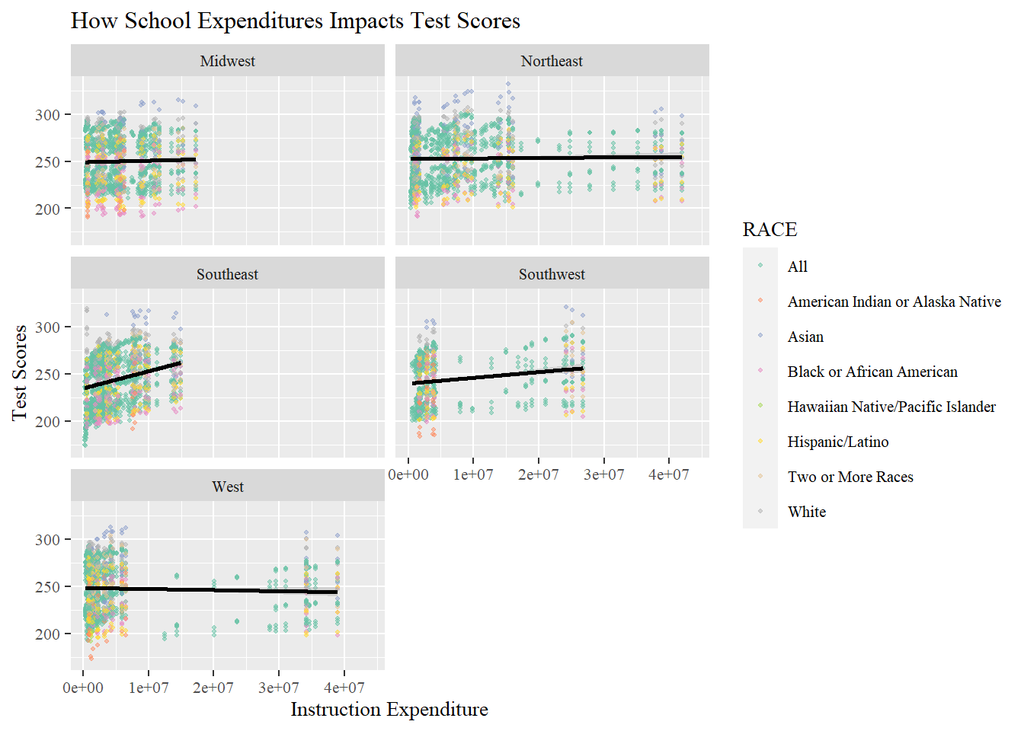

## Figure 2

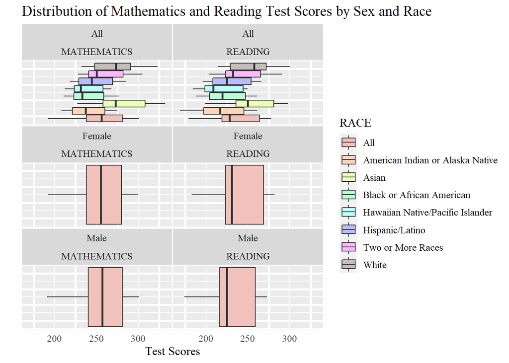

## Figure 3

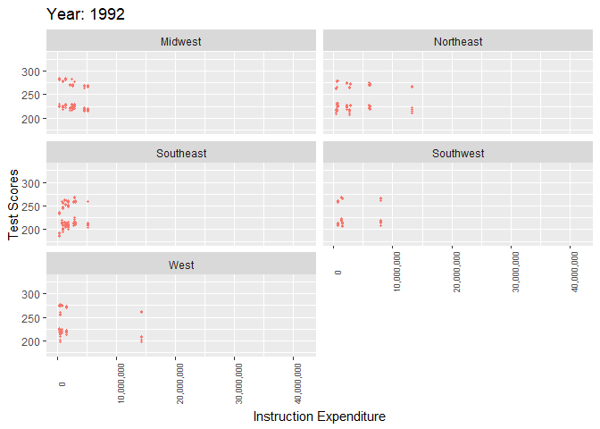

Figure 3 shows how the relationship between instructional expenditures and test scores change over time in five regions within the United States. All 5 regions have lower instruction expenditures and test scores throughout the 90s. In the 2000s a gap between high and low instruction expenditures developed, especially in the West, Southwest and Northeast, while the Midwest and Southeast maintained relatively low instruction expenditures. Although all regions demonstrate an increase in the distribution of test scores over time, only the Southeast and Southwest demonstrated a slight positive relationship between school expenditures and test scores.

## Figure 4

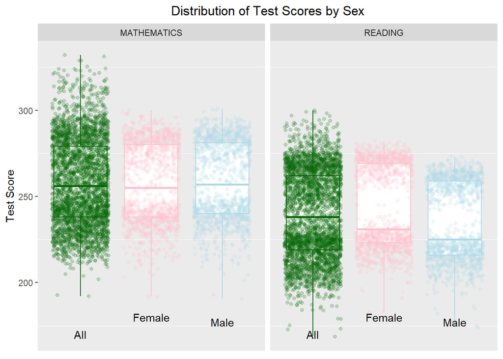

How school instructional expenditures and test scores have changed over time, and how this differs by region

Each of these visualizations should also investigate how these relationships differ based on student race and sex.

# Linear Regression

To begin with, we created two simple models to analyze if there is any difference between the mathematics and reading tests when it came to predicting test scores from instructions expenditure. To measure the accuracy of the models, we decided to use the R-squared statistic, which measures the variability accounted for in the response variable (test scores) due to the explanatory variable (instructional expenditure).

### Relationship between instructional expenditures and *mathematics* test scores

```
##
## Call:
## lm(formula = TEST_SCORES ~ INSTRUCTION_EXPENDITURE, data = .)
##
## Residuals:
##     Min      1Q  Median      3Q     Max
## -65.296 -19.955  -2.694  22.593  72.342
##
## Coefficients:
##                          Estimate Std. Error t value Pr(>|t|)
## (Intercept)             2.562e+02  5.003e-01 512.165  < 2e-16 ***
## INSTRUCTION_EXPENDITURE 2.238e-07  5.312e-08   4.214 2.57e-05 ***
## ---
## Signif. codes:  0 '***' 0.001 '**' 0.01 '*' 0.05 '.' 0.1 ' ' 1
##
## Residual standard error: 24.45 on 3910 degrees of freedom
##   (29748 observations deleted due to missingness)
## Multiple R-squared:  0.004521,   Adjusted R-squared:  0.004266
## F-statistic: 17.76 on 1 and 3910 DF,  p-value: 2.566e-05
```

### Relationship between instructional expenditures and *reading* test scores

```
##
## Call:
## lm(formula = TEST_SCORES ~ INSTRUCTION_EXPENDITURE, data = .)
##
## Residuals:
##     Min      1Q  Median      3Q     Max
## -64.992 -20.308  -7.211  23.699  61.169
##
## Coefficients:
##                          Estimate Std. Error t value Pr(>|t|)
## (Intercept)             2.377e+02  4.876e-01 487.517  < 2e-16 ***
## INSTRUCTION_EXPENDITURE 2.098e-07  5.250e-08   3.995 6.57e-05 ***
## ---
## Signif. codes:  0 '***' 0.001 '**' 0.01 '*' 0.05 '.' 0.1 ' ' 1
##
## Residual standard error: 24.59 on 4147 degrees of freedom
##   (29511 observations deleted due to missingness)
## Multiple R-squared:  0.003835,   Adjusted R-squared:  0.003594
## F-statistic: 15.96 on 1 and 4147 DF,  p-value: 6.57e-05
```

## Multiple Linear Regression

### Both Tests

```
##
## Call:
## lm(formula = TEST_SCORES ~ INSTRUCTION_EXPENDITURE + TEST, data = .)
##
## Residuals:
##     Min      1Q  Median      3Q     Max
## -65.336 -20.120  -5.192  23.161  72.410
##
## Coefficients:
##                           Estimate Std. Error t value Pr(>|t|)
## (Intercept)              2.563e+02  4.493e-01 570.344  < 2e-16 ***
## INSTRUCTION_EXPENDITURE  2.167e-07  3.734e-08   5.803 6.77e-09 ***
## TESTREADING             -1.859e+01  5.466e-01 -34.017  < 2e-16 ***
## ---
## Signif. codes:  0 '***' 0.001 '**' 0.01 '*' 0.05 '.' 0.1 ' ' 1
##
## Residual standard error: 24.53 on 8058 degrees of freedom
##   (59259 observations deleted due to missingness)
## Multiple R-squared:  0.129,  Adjusted R-squared:  0.1288
## F-statistic: 596.8 on 2 and 8058 DF,  p-value: < 2.2e-16
```

To account for the test, instead of creating two separate models, we incorporated the **test** variable as a categorical predictor in the equation. We also believed that the **year** of the observation would be important, since we imagined that expenditure would increase in tandem with inflation and the overall standard of living in the United States. After adding these two variables into our model, our R-squared had increased to 0.1569, or 15.69% of variability in the test scores accounted for. Better, but still not ideal.

```
##
## Call:
## lm(formula = TEST_SCORES ~ INSTRUCTION_EXPENDITURE + TEST + YEAR,
##     data = .)
##
## Residuals:
##    Min     1Q Median     3Q    Max
## -68.88 -19.62  -5.65  23.31  68.81
##
## Coefficients:
##                           Estimate Std. Error t value Pr(>|t|)
## (Intercept)             -1.195e+03  8.839e+01 -13.525  < 2e-16 ***
## INSTRUCTION_EXPENDITURE  1.117e-07  3.728e-08   2.996  0.00275 **
## TESTREADING             -1.830e+01  5.380e-01 -34.016  < 2e-16 ***
## YEAR                     7.230e-01  4.402e-02  16.424  < 2e-16 ***
## ---
## Signif. codes:  0 '***' 0.001 '**' 0.01 '*' 0.05 '.' 0.1 ' ' 1
##
## Residual standard error: 24.13 on 8057 degrees of freedom
##   (59259 observations deleted due to missingness)
## Multiple R-squared:  0.1572, Adjusted R-squared:  0.1569
## F-statistic:   501 on 3 and 8057 DF,  p-value: < 2.2e-16
```

## Adjusting for Complexity

There is a trade off between model “complexity” and an increase in a model’s R2. Unfortunately, even if a variable doesn’t add much to the model, the R2 for that model will still increase. So, we need a different measure that can account for whether the variable(s) explain components of the variability in test scores that weren’t accounted for by other variables.

This is where adjusted R2 comes in. By “adjusting” the R2, we are essentially making a penalty for whether the extra variable added something “new” to the model.

Include additional variables in your regression and see how much variability in test scores your model can account for. Use adjusted R2 to decide on what final model your group believes is the “best.”

Again, we decided to add some seemingly relavent variables to our model to see if it improved our R-squared. One of the variables was **GRADE** because we had a hypothesis that the grade in which the student in presumably affects their tests score. More specifically, we thought that a higher grade would result in a higher test score, since the student would have more knowledge and therefore more capable of achieving a better score. The other variable we accounted for is **Region**. Different regions most likely spend different amounts of money on education, so we wanted to have that reflected in our model. Also by including regions, we could potentially see which regions were scoring lower or higher on the tests, and see if there was any correlation between the region and the test score. After adding these two variables (**GRADE** and **Region**), our R-squared was now 0.8464, meaning that almost 85% of the variability in the observed test scores was being accounted for by the explanatory variables we included in our model. This is much better, and now some deductions could be made.

```
##
## Call:
## lm(formula = TEST_SCORES ~ INSTRUCTION_EXPENDITURE + TEST + YEAR +
##     GRADE + Region, data = .)
##
## Residuals:
##     Min      1Q  Median      3Q     Max
## -47.419  -5.680   1.150   6.444  43.888
##
## Coefficients:
##                           Estimate Std. Error t value Pr(>|t|)
## (Intercept)             -7.109e+02  3.792e+01 -18.748  < 2e-16 ***
## INSTRUCTION_EXPENDITURE  5.135e-08  1.617e-08   3.176   0.0015 **
## TESTREADING             -1.702e+01  2.298e-01 -74.075  < 2e-16 ***
## YEAR                     4.723e-01  1.889e-02  25.007  < 2e-16 ***
## GRADE8                   4.327e+01  2.303e-01 187.867  < 2e-16 ***
## RegionNortheast          3.316e+00  3.480e-01   9.529  < 2e-16 ***
## RegionSoutheast         -6.155e+00  3.289e-01 -18.715  < 2e-16 ***
## RegionSouthwest         -5.732e+00  4.632e-01 -12.374  < 2e-16 ***
## RegionWest              -2.421e+00  3.426e-01  -7.064 1.75e-12 ***
## ---
## Signif. codes:  0 '***' 0.001 '**' 0.01 '*' 0.05 '.' 0.1 ' ' 1
##
## Residual standard error: 10.3 on 8052 degrees of freedom
##   (59259 observations deleted due to missingness)
## Multiple R-squared:  0.8465, Adjusted R-squared:  0.8464
## F-statistic:  5552 on 8 and 8052 DF,  p-value: < 2.2e-16
```

With your final model, make a visualization that explores the relationships accounted for in your model.

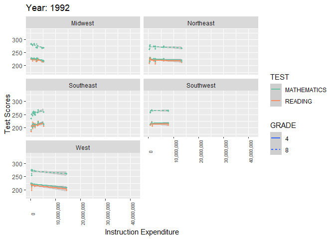

With your chosen model, generate predictions using the predict() function. Then, add random errors to the predictions, using the residual standard error estimated from the linear regression model (acquired with sigma()).

Tip: Measure the R-squared between expected vs observed values, SSE, and RMSE

Now, compare these simulated observations to the observed data. Generate the same plot of the relationships modeled by the linear regression, for the simulated data (that you made at the end of Part One). Plot the visualization of the observed data and the simulated data side-by-side. Discuss how the simulated data are similar and / or different to the observed data.

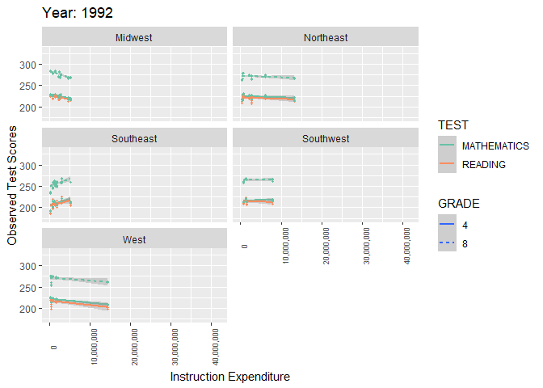

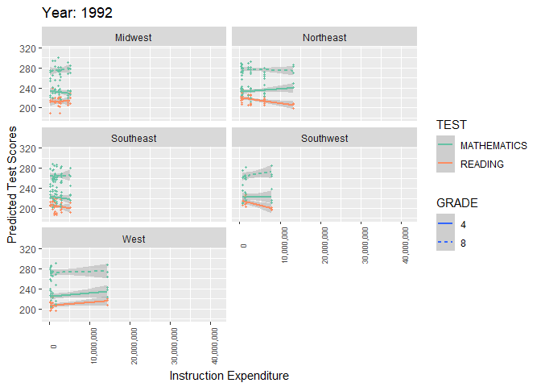

```
## * sim -> sim...1
## * sim -> sim...2
## * sim -> sim...3
## * sim -> sim...4
## * sim -> sim...5
## * ...
```

```
## * sim...1 -> sim...2
## * sim...2 -> sim...3
## * sim...3 -> sim...4
## * sim...4 -> sim...5
## * sim...5 -> sim...6
## * ...
```

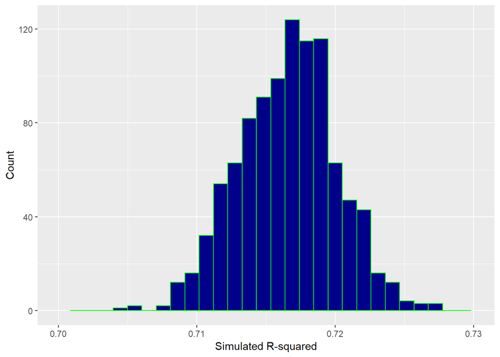